# Using R for Data Analysis

2019-04-18

## Using R for Data Analysis (urfda 2019)

[figure not shown]

## Global course aims

- Get acquainted with the Data Science Toolbox in R
- An introduction to R and the Integrated Development Environment "RStudio"
- Learn how to appply R-programming in every day data analysis flow
- Discover the strong graphical plotting powers of R (ggplot2)
- Implement literate programming to report data cleaning and analysis
- Discover R-packages
- Apply the `tidyverse` packages to common data science problems and challenges
- Learn about functional programming in R
- …

## Course schedule

Each day: Introduction of the daily goals, Recap of previous day

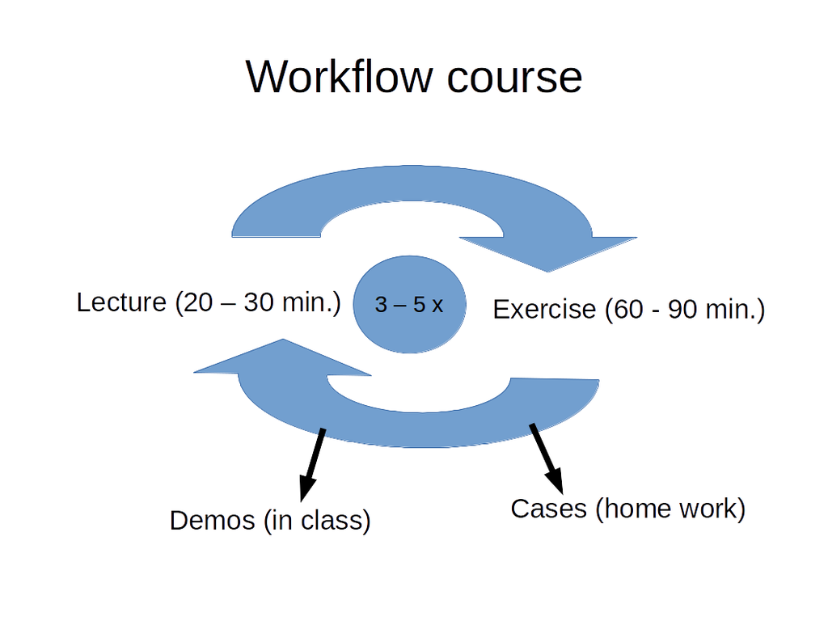

## Course Materials

[figure not shown]

- www.github.com/uashogeschoolutrecht/urfda_2019
- "R for Data Science" by Wickham and Grolemund, 2017

For more details see "course_activities.html"

## Day 1: Introduction & Workflow

- Introduction Data Science
- R and RStudio
- RStudio Server
- Github.com
- Intalling packages
- Intro to R
- Writing code / Workflow
- RMarkdown documents
- (`{dplyr - Data Wrangling}`)

## Day 2:

- Data wrangling with {dplyr}
- Visualizations with {ggplot2}
- Animations with {gganimate}
- Import data {readr} & {readxl}

## Day 3:

- Strings
- Regular expressions
- Factors
- Tidy data with {tidyr}
- Exploratory data analysis
- Statistics: exploring assumptions
- Getting to models (resources)

## Day 4: Function programming in R

- General programming rules
- Vectors
- Pipes
- Loops
- iteration specials
- Writing functions

## Day 5: Reproducibility

- Literate programming
- Managing many models
- Building R packages

## Day 6:

- Datasets and cases
- Spare / buffer

## Course materials

- All materials (scripts, slides etc) can be found at

https://github.com/uashogeschoolutrecht/urfda_2019

- Getting R and RStudio:

login to: http://rcourses.hudatascience.nl with the credentials provided

## Additional resources

- Many online tools available http://r4ds.had.co.nz/
- Primary literature and datasets for the case examples
- R-help pages (`help.start()`)
- http://www.Stackoverflow.com

See "resources.html" for more tips

## Lab structure #1

```r
fs::dir_tree(here::here("labs", "01_lab_course_intro"))
```

[output not shown]

```r
fs::dir_tree(here::here("labs", "06_lab_intro_to_r"))
```

[output not shown]